# Exploring the BRFSS data by MOHIT SHAH

## Setup

### Load packages

```r
library(ggplot2)
library(dplyr)
```

### Load data

```r
load("brfss2013.RData")
```

## Part 1: Data

The BRFSS user guide on the website says that they have used **disproportionate stratified sampling** which is a technique of random sampling to collect the data. But the random sampling is done only on the adults in the US who have some residence and are not institutionalized. Hence the observations made from this study can be **generalized to adults in US who have some sort of residence like household,private residence or college and are not instituionalized**. For example it cannot be generalized to homeless people or people outside US as the sample is not representative of them.

Random assignment is not used here because adults are not randomly assigned to groups and the causal environment applied on them. **This is an observational study because only random sampling is used and not random assignment. Hence we cannot make any inferences about causality.**

## Part 2: Research questions

**Research quesion 1:**

Is there a relationship between how often the person drinks regular soda or pop and has a difficulty in concentrating and remembering?

I think this is important as I would like to know if there is an association between drinking soda/pop and difficulty in concentrating and remembering.

The variables involved are **ssbsugar,decide.**

**Research quesion 2:**

Is there a relationship between number of work hours and having high blood pressure or hypertension?

What I want to figure out is, is there a positive association between working more hours and having high blood pressure.

The variables involved are **scntlwk1,bphigh4.**

**Research quesion 3:**

Is there any relationship between the number of days in a month a person drinks and number of days a person feels depressed?

I want to find out that is there a positive association between depression and drinking.

The variables involved are **alcday5,qlmentl2.**

## Part 3: Exploratory data analysis

### Research quesion 1:

#### Structuring the data

First I will add a new column called sugardrinks_month which will contain number of sugar drinks by an individual per month.

If value in ssbsugar column is

[101-199] - then 1 is for per day and the remaining digits show number of drinks/day hence mod 100 multiply by 30

[201-299] - 2 is for week and and remaining digits show number of drinks/week hence mod 100 multiply by 4

[301-399] - 3 is for month and and remaining digits show number of drinks/month hence mod 100 multiply by 1

else the value will stay as it is.

Hence to convert all this to uniform data of number of drinks/month I used following command

```r
brfss2013 <- brfss2013  %>% mutate(sugardrinks_month = ifelse(is.na(ssbsugar),ssbsugar,
                                                       ifelse(ssbsugar>=301,ssbsugar%%100,
                                                       ifelse(ssbsugar>=201,(ssbsugar%%100)*4,
                                                       ifelse(ssbsugar>=101,(ssbsugar%%100)*30,ssbsugar)))))
```

Here is the new column compared to old one (Taking first 10 rows)

```r
head(brfss2013 %>% filter(!is.na(ssbsugar))%>%select(ssbsugar,sugardrinks_month),10)
```

```
##    ssbsugar sugardrinks_month
## 1       305                 5
## 2       203                12
## 3       202                 8
## 4       203                12
## 5       102                60
## 6         0                 0
## 7         0                 0
## 8         0                 0
## 9       301                 1
## 10        0                 0
```

#### Summarization and Plots

Following is the summary of the variables sugardrinks_month and decide after getting rid of NA from the data. I have also added the count and the frequency. The frequency is for example the count of the people drinking 1200 drinks a month divided by total number of people in that group(“Yes” or “No”). Then I have taken only 20 rows in descending order of number of sugar drinks consumed.

```r
temp <- brfss2013 %>% filter(!is.na(sugardrinks_month),!is.na(decide)) %>% group_by(decide,sugardrinks_month) %>% summarize(count = n()) %>% mutate(freq = count/sum(count))

head(temp[with(temp, order(-sugardrinks_month)), ],20)
```

```
## # A tibble: 20 x 4
## # Groups:   decide [2]
##    decide sugardrinks_month count         freq
##    <fctr>             <dbl> <int>        <dbl>
##  1    Yes              1200     1 9.196248e-05
##  2     No              1200     1 1.088826e-05
##  3    Yes               900     2 1.839250e-04
##  4     No               900     2 2.177653e-05
##  5    Yes               720     3 2.758874e-04
##  6     No               630     1 1.088826e-05
##  7    Yes               600     2 1.839250e-04
##  8     No               600     2 2.177653e-05
##  9     No               450     4 4.355306e-05
## 10     No               420     1 1.088826e-05
## 11    Yes               390     1 9.196248e-05
## 12    Yes               360    19 1.747287e-03
## 13     No               360    28 3.048714e-04
## 14    Yes               330     1 9.196248e-05
## 15     No               330     1 1.088826e-05
## 16    Yes               300    18 1.655325e-03
## 17     No               300    36 3.919775e-04
## 18     No               270     3 3.266479e-05
## 19    Yes               240    22 2.023175e-03
## 20     No               240    37 4.028658e-04
```

From the summary it appears that people who consume more sugar drinks have more problem concentrating as the difference in frequencies between both values of decide(“Yes” and “No”) for same values of number of sugar drinks is quite large.

First let me plot for each group in decide variable the number of sugardrinks_month

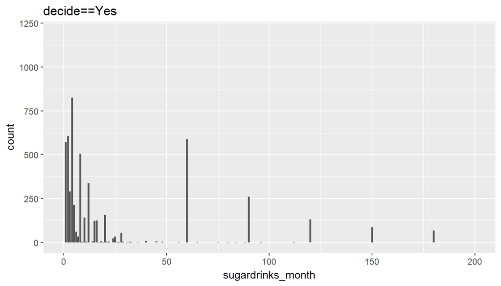

```r
brfss2013 %>% filter(!is.na(sugardrinks_month),!is.na(decide),decide=="Yes") %>% ggplot(aes(x=sugardrinks_month)) + geom_bar() + scale_x_continuous(limits=c(0,200)) + scale_y_continuous(limits=c(0,1200)) + ggtitle("decide==Yes")
```

For decide==“no”

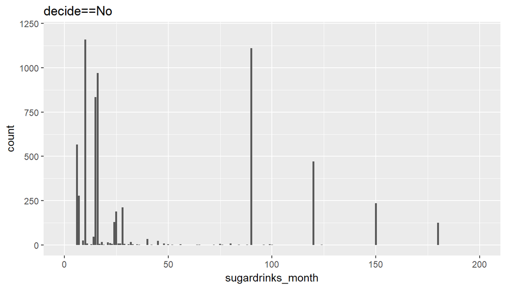

```r
brfss2013 %>% filter(!is.na(sugardrinks_month),!is.na(decide),decide=="No") %>% ggplot(aes(x=sugardrinks_month)) + geom_bar() + scale_x_continuous(limits=c(0,200)) +scale_y_continuous(limits=c(0,1200)) + ggtitle("decide==No")
```

Clearly the **plots are right skewed and in case of skewed plots I should be taking median into consideration.**

Following is the summary of the new numerical variable sugardrinks_month for each group in decide variable. Those who have problem concentrating and those who don’t.

```r
brfss2013 %>% filter(!is.na(sugardrinks_month),!is.na(decide)) %>% group_by(decide)%>% summarize(sugardrinks_mean = mean(sugardrinks_month),sugardrinks_median = median(sugardrinks_month),sugardrinks_sd = sd(sugardrinks_month),sugardrinks_min = min(sugardrinks_month),sugardrinks_max = max(sugardrinks_month))
```

```
## # A tibble: 2 x 6
##   decide sugardrinks_mean sugardrinks_median sugardrinks_sd
##   <fctr>            <dbl>              <dbl>          <dbl>
## 1    Yes         17.88670                  3       42.84720
## 2     No          9.96151                  1       24.27223
## # ... with 2 more variables: sugardrinks_min <dbl>, sugardrinks_max <dbl>
```

From the summary I can observe that the difference between the two medians is very less to come to any conclusion.

I have used box plot for this as there is one categorical variable (“decide”) and one numerical variable (“sugardrinks_month”). I have kept a limit on the y axis so that the box plots can be seen clearly as sugardrinks_month ’s value can go upto 1200

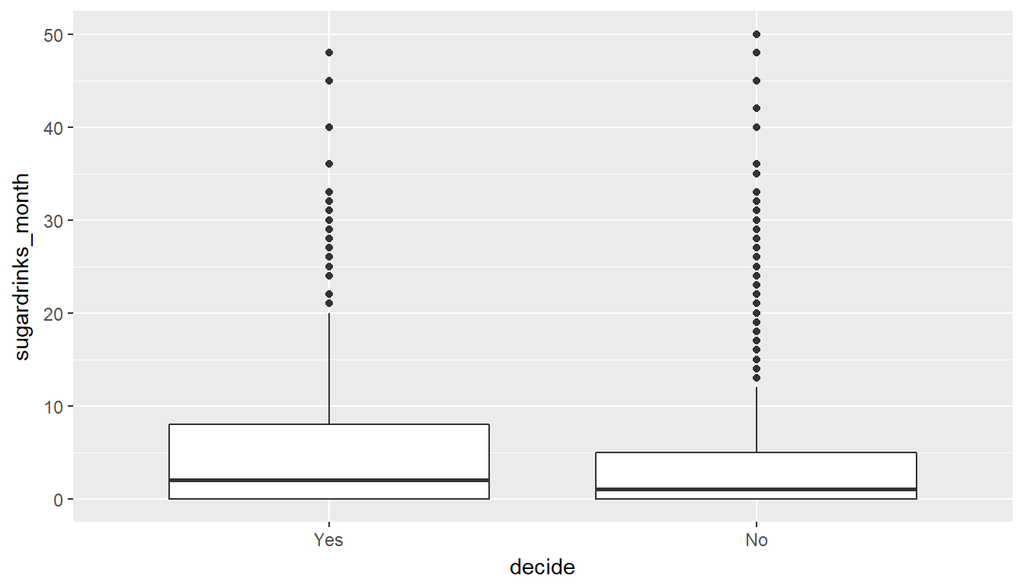

```r
brfss2013 %>% filter(!is.na(sugardrinks_month),!is.na(decide)) %>% ggplot(aes(x=decide,y=sugardrinks_month)) +
  geom_boxplot() + scale_y_continuous(limits = c(0,50))
```

#### Conclusion

The spread of group of people with problems is greater than the spread of people who don’t have any. The median of the first group is only marginally larger than the second one hence I am not able to see any association between the two variables. Hence one cannot comment on positive association.

### Research quesion 2:

#### Structuring the data

Here I am dealing with two variables (work hours in a week)scntlwk1 and (if told high blood pressure)bphigh4. I will summarize the values of bphigh4 as follows

```r
str(brfss2013$bphigh4)
```

```
##  Factor w/ 4 levels "Yes","Yes, but female told only during pregnancy",..: 1 3 3 3 1 1 1 1 3 3 ...
```

I will create an new column HighBP which will contain “Yes” only if bphigh4 is “Yes”. For all other non “NA” levels HighBP will be “NO” and for “NA” levels it will be “NA”.

```r
brfss2013 <- brfss2013  %>% mutate(HighBP = ifelse(bphigh4 == "Yes","Yes",ifelse(!is.na(bphigh4),"No",bphigh4)))
```

Here is the new column compared to old one (Taking first 10 rows)

```r
head(brfss2013 %>% select(bphigh4,HighBP),10)
```

```
##    bphigh4 HighBP
## 1      Yes    Yes
## 2       No     No
## 3       No     No
## 4       No     No
## 5      Yes    Yes
## 6      Yes    Yes
## 7      Yes    Yes
## 8      Yes    Yes
## 9       No     No
## 10      No     No
```

#### Summarization

Following is the summary of the variables scntlwk1 and HighBP after getting rid of NA from the data.Also I am calculating the count and the frequency.I am ordering in descending order by scntlwk1(number of work hours) and taking top 20 rows.

```r
temp <- brfss2013 %>% filter(!is.na(scntlwk1),!is.na(HighBP)) %>% group_by(HighBP,scntlwk1) %>% summarize(count = n()) %>% mutate(freq=count/sum(count))

head(temp[with(temp, order(-scntlwk1)), ],20)
```

```
## # A tibble: 20 x 4
## # Groups:   HighBP [2]
##    HighBP scntlwk1 count         freq
##     <chr>    <int> <int>        <dbl>
##  1     No       98   165 1.832315e-02
##  2    Yes       98   211 1.727526e-02
##  3     No       96    39 4.330927e-03
##  4    Yes       96    32 2.619944e-03
##  5    Yes       94     3 2.456198e-04
##  6     No       90    16 1.776791e-03
##  7    Yes       90    21 1.719338e-03
##  8     No       87     2 2.220988e-04
##  9    Yes       87     1 8.187326e-05
## 10     No       86     2 2.220988e-04
## 11     No       85     6 6.662965e-04
## 12    Yes       85     4 3.274930e-04
## 13     No       84    13 1.443642e-03
## 14    Yes       84    22 1.801212e-03
## 15     No       82     2 2.220988e-04
## 16     No       80    79 8.772904e-03
## 17    Yes       80   127 1.039790e-02
## 18    Yes       79     1 8.187326e-05
## 19     No       78     1 1.110494e-04
## 20     No       77     3 3.331483e-04
```

From this summarization there doesn’t seem to be any clear association between number of work hours and high blood pressure as the frequency for those with HighBP and same number of work hours is sometimes less than those without HighBP or a few times greater.

Following is the Statistical summary of scntlwk1 with respect to both levels of HighBP(“Yes” and “No”)

```r
brfss2013 %>% filter(!is.na(scntlwk1),!is.na(HighBP)) %>% group_by(HighBP) %>% summarize(workhours_mean = mean(scntlwk1),workhours_median = median(scntlwk1),workhours_sd = sd(scntlwk1),workhours_min = min(scntlwk1),workhours_max = max(scntlwk1))
```

```
## # A tibble: 2 x 6
##   HighBP workhours_mean workhours_median workhours_sd workhours_min
##    <chr>          <dbl>            <dbl>        <dbl>         <dbl>
## 1     No       42.09717               40     15.42689             1
## 2    Yes       41.92803               40     14.97660             0
## # ... with 1 more variables: workhours_max <dbl>
```

The means and the medians of number of work hours for both groups are same here hence there can be no conclusion regarding association.

#### Plot

I have used box plot for this as there is one categorical variable (“HighBP”) and one numerical variable (“scntlwk1”).

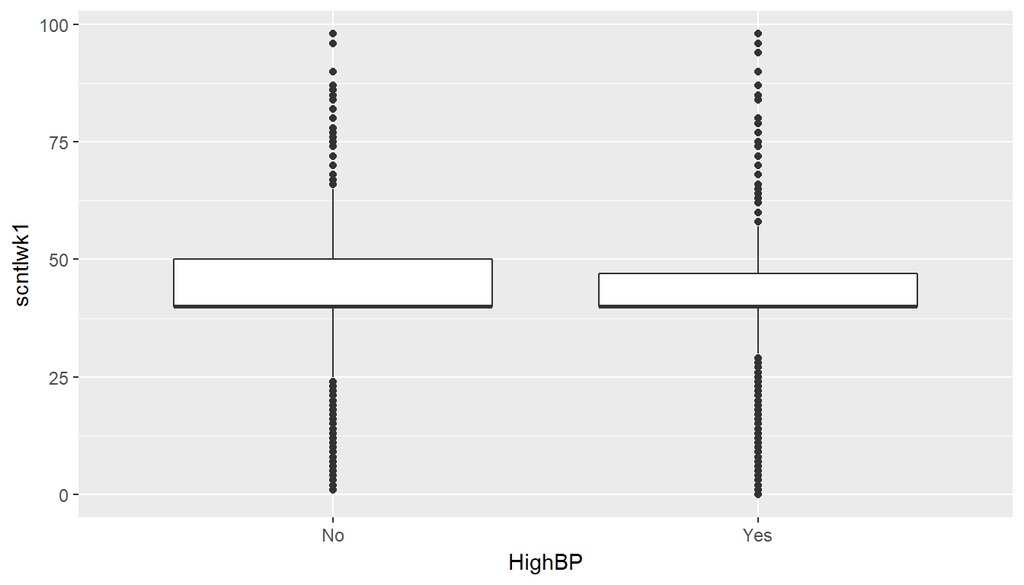

```r
brfss2013 %>% filter(!is.na(HighBP),!is.na(scntlwk1)) %>% ggplot(aes(x=HighBP,y=scntlwk1)) +
  geom_boxplot()
```

#### Conclusion

Again I cannot make any association between having high blood pressure and number of work hours as their medians are almost the same. Contrary to the expected positive association the spread of people not having high BP is more.

### Research quesion 3:

#### Structuring the data

I am working with variables alcday5(number of days person was drinking in a week or a month) and qlmentl2(number of days a person is depressed in a month). For number of days in past month an adult had a drink I will have to create a new variable days_month.

alcday5 has value

[101-199] - where 1 is for week and rest digits show number of days/per week hence mod 100 multiply by 4.

[201-299] - where 2 is for month and rest digits show number of days/per month hence mod 100 multiply by 1.

else it will be same as alcday5.

```r
brfss2013 <- brfss2013  %>% mutate(days_month = ifelse(alcday5>=201,alcday5%%100,ifelse(alcday5>=101,alcday5%%100*4,alcday5)))
```

Here is the new column compared to old one (Taking first 10 rows)

```r
head(brfss2013 %>% select(alcday5,days_month),10)
```

```
##    alcday5 days_month
## 1      201          1
## 2        0          0
## 3      220         20
## 4      208          8
## 5      210         10
## 6        0          0
## 7      201          1
## 8      202          2
## 9      101          4
## 10       0          0
```

#### Summarization

Following is the summary of the variables qlmentl2 and days_month after getting rid of NA from the data. I have computed the mean and median number of days for each value of qlment12.

```r
brfss2013 %>% filter(!is.na(qlmentl2),!is.na(days_month)) %>% group_by(qlmentl2) %>% summarize(count = n(),mean_days=mean(days_month),median_days=median(days_month))
```

```
## # A tibble: 18 x 4
##    qlmentl2 count  mean_days median_days
##       <int> <int>      <dbl>       <dbl>
##  1        0   276  2.8876812           0
##  2        1    21  1.5238095           0
##  3        2    31  2.3225806           0
##  4        3    32  3.3750000           0
##  5        4    12  1.8333333           0
##  6        5    14  1.3571429           0
##  7        6     9  0.8888889           0
##  8        7     5  0.4000000           0
##  9        8     3  1.0000000           1
## 10       10    12  2.5833333           0
## 11       12     1  0.0000000           0
## 12       14     3  0.0000000           0
## 13       15    22  4.7727273           0
## 14       16     1  1.0000000           1
## 15       20     6  0.5000000           0
## 16       25     5  0.0000000           0
## 17       29     1 15.0000000          15
## 18       30    35  3.2000000           0
```

From the summary it can be seen that it is there is no association between people who are depressed on more number of days and drinking on more number of days in a month because neither the mean nor median value of number of days a person drinks are increasing as the value of qlment12 is increasing.

#### Plots

I have used scatter plot for this as there are two numerical variables.

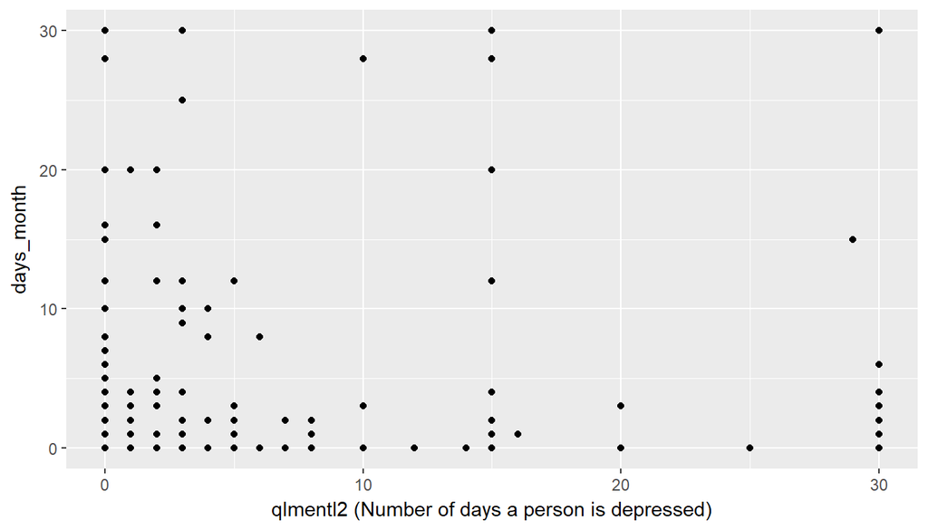

```r
brfss2013 %>% filter(!is.na(days_month),!is.na(qlmentl2)) %>% ggplot(aes(x=qlmentl2,y=days_month)) +
  geom_point() + xlab("qlmentl2 (Number of days a person is depressed)")
```

#### Conclusion

Again I cannot make any association between number of days of depression in a month and number of days a person has drinks in a month from the scatterplot.